# Modelos de clasificación - Clase 7

Cecilia Oliva

18/06/2024

# Test de Hotelling

## Ejemplo

Retomamos el ejemplo de la clase pasada para el cual ya aplicamos regresión logística.

Se observaron dos grupos de salmones: de Alaska y de Canadá. Se determinó el número de una sustancia química producida por su permanencia en agua dulce o en el mar. Se quiere establecer un modelo que prediga de qué origen es el salmón conociendo ambas cantidades de sustancias. (Se sabe que los salmones migran de océanos a ríos y al revés).

```r
library(ggplot2)
library(ggpubr)
library(readxl)
salmon <- read_excel("salmon.xlsx")
```

Analizamos los supuestos de normalidad multivariada y homocedasticidad. Luego aplicamos el test de Hotelling para saber si hay diferencia de vectores medios.

```r
library(mvnormtest)
mshapiro.test(t(salmon[salmon$origen=="Alaska",-1]))
```

```
##
##  Shapiro-Wilk normality test
##
## data:  Z
## W = 0.97412, p-value = 0.3376
```

```r
mshapiro.test(t(salmon[salmon$origen=="Canada",-1]))
```

```
##
##  Shapiro-Wilk normality test
##
## data:  Z
## W = 0.96853, p-value = 0.2016
```

No se rechaza la normalidad multivariada en ninguno de los dos grupos.

Analizamos homocedasticidad.

```r
library(biotools)
boxM(data =salmon[,-1], grouping = salmon$origen)
```

```
##
##  Box's M-test for Homogeneity of Covariance Matrices
##
## data:  salmon[, -1]
## Chi-Sq (approx.) = 10.696, df = 3, p-value = 0.01349
```

Según el test M de Box no se satisfce el supuesto de homocedasticidad a nivel 5%, pero si tomamos como nivel de significancia 1% no rechazaríamos el test.

Apliquemos el test de Hotelling.

```r
library(corpcor)
library(Hotelling)
T2test = hotelling.test(.~ origen, data =salmon)
T2test
```

```
## Test stat:  207.3
## Numerator df:  2
## Denominator df:  97
## P-value:  0
```

El test rechaza igualdad de vectores medios, es decir que tiene sentido armar un modelo supervisado que trate de predecir las distintas clases.

# Análisis discriminante lineal (LDA)

```r
library(MASS)

# LDA

salmon_lda0 <- lda(origen ~ aguadulce+mar, data = salmon)
salmon_lda0
```

```
## Call:
## lda(origen ~ aguadulce + mar, data = salmon)
##
## Prior probabilities of groups:
## Alaska Canada
##    0.5    0.5
##
## Group means:
##        aguadulce    mar
## Alaska     98.38 429.66
## Canada    137.46 366.62
##
## Coefficients of linear discriminants:
##                   LD1
## aguadulce  0.04458572
## mar       -0.01803856
```

### clasificación cv-loo

```r
salmon_lda <- lda(origen ~ aguadulce+mar, data = salmon,CV=TRUE)
salmon_lda
```

```
## $class
##   [1] Canada Canada Alaska Alaska Alaska Alaska Alaska Alaska Alaska Alaska
##  [11] Alaska Canada Canada Alaska Alaska Alaska Alaska Alaska Alaska Alaska
##  [21] Alaska Alaska Alaska Alaska Alaska Alaska Alaska Alaska Alaska Canada
##  [31] Alaska Canada Alaska Alaska Alaska Alaska Alaska Alaska Alaska Alaska
##  [41] Alaska Alaska Alaska Alaska Alaska Alaska Alaska Alaska Alaska Alaska
##  [51] Canada Canada Canada Canada Canada Canada Canada Canada Canada Canada
##  [61] Canada Canada Canada Canada Canada Canada Canada Canada Canada Canada
##  [71] Alaska Canada Canada Canada Canada Canada Canada Canada Canada Canada
##  [81] Canada Canada Canada Canada Canada Canada Canada Canada Canada Canada
##  [91] Canada Canada Canada Canada Canada Canada Canada Canada Canada Canada
## Levels: Alaska Canada
##
## $posterior
##           Alaska       Canada
```

[output cut: 131 more lines]

```r
table(salmon_lda$class,salmon$origen)
```

```
##
##          Alaska Canada
##   Alaska     44      1
##   Canada      6     49
```

```r
TasaBuenaclasif_lda<-mean(salmon_lda$class==salmon$origen)# tasa de buena clasificación del discr. lineal
TasaBuenaclasif_lda
```

```
## [1] 0.93
```

```r
error_cvloo_lda<-mean(salmon_lda$class!=salmon$origen)# tasa de error
error_cvloo_lda
```

```
## [1] 0.07
```

### Clasificación con entrenamiento y validación

```r
set.seed(2019)
entrenamiento<-sample(1:100,70)
validación<-c(1:100)[-entrenamiento]
salmon_lda1 <- lda(origen ~ aguadulce+mar, data = salmon[entrenamiento,])
salmon_lda1
```

```
## Call:
## lda(origen ~ aguadulce + mar, data = salmon[entrenamiento, ])
##
## Prior probabilities of groups:
##    Alaska    Canada
## 0.5285714 0.4714286
##
## Group means:
##        aguadulce      mar
## Alaska  99.43243 427.0811
## Canada 136.42424 360.5152
##
## Coefficients of linear discriminants:
##                   LD1
## aguadulce  0.04268329
## mar       -0.01830921
```

```r
prediccionesLda_2 <- predict(object = salmon_lda1, newdata = salmon[validación,-1])
table(salmon$origen[validación], prediccionesLda_2$class, dnn = c("Origen real", "Origen predicho"))
```

```
##            Origen predicho
## Origen real Alaska Canada
##      Alaska     12      1
##      Canada      2     15
```

```r
error_test_lda<- mean(salmon$origen[validación] != prediccionesLda_2$class) * 100
error_test_lda
```

```
## [1] 10
```

# Análisis discriminante cuadrático (QDA)

Recordar que el análisis discriminante cuadrático no requiere validar el supuesto de homocedasticidad (sí el de normalidad multivariada).

```r
salmon_qda0 <- qda(origen ~ aguadulce+mar, data = salmon)
salmon_qda0
```

```
## Call:
## qda(origen ~ aguadulce + mar, data = salmon)
##
## Prior probabilities of groups:
## Alaska Canada
##    0.5    0.5
##
## Group means:
##        aguadulce    mar
## Alaska     98.38 429.66
## Canada    137.46 366.62
```

### clasificación cv-loo

```r
salmon_qda <- qda(origen ~ aguadulce+mar, data = salmon,CV=TRUE)
salmon_qda
```

```
## $class
##   [1] Canada Canada Alaska Alaska Alaska Alaska Alaska Alaska Alaska Alaska
##  [11] Alaska Canada Canada Alaska Alaska Alaska Alaska Alaska Alaska Alaska
##  [21] Alaska Alaska Alaska Alaska Alaska Alaska Alaska Alaska Alaska Canada
##  [31] Alaska Alaska Alaska Alaska Alaska Alaska Alaska Alaska Alaska Alaska
##  [41] Alaska Alaska Alaska Alaska Alaska Alaska Alaska Alaska Alaska Alaska
##  [51] Alaska Canada Canada Canada Canada Canada Canada Canada Canada Canada
##  [61] Canada Canada Canada Canada Canada Canada Canada Alaska Canada Canada
##  [71] Alaska Canada Canada Canada Canada Canada Canada Canada Canada Canada
##  [81] Canada Canada Canada Canada Canada Canada Canada Canada Canada Canada
##  [91] Canada Canada Canada Canada Canada Canada Canada Canada Canada Canada
## Levels: Alaska Canada
##
## $posterior
##           Alaska       Canada
```

[output cut: 131 more lines]

```r
table(salmon_qda$class,salmon$origen)
```

```
##
##          Alaska Canada
##   Alaska     45      3
##   Canada      5     47
```

```r
TasaBuenaclasif_qda<-mean(salmon_qda$class==salmon$origen)# tasa de buena clasificación del discr cuadrático
TasaBuenaclasif_qda
```

```
## [1] 0.92
```

```r
error_cvloo_qda<-mean(salmon_qda$class!=salmon$origen)# tasa de error
error_cvloo_qda
```

```
## [1] 0.08
```

### Clasificación con entrenamiento y validación

```r
salmon_qda1 <- qda(origen ~ aguadulce+mar, data = salmon[entrenamiento,])
salmon_qda1
```

```
## Call:
## qda(origen ~ aguadulce + mar, data = salmon[entrenamiento, ])
##
## Prior probabilities of groups:
##    Alaska    Canada
## 0.5285714 0.4714286
##
## Group means:
##        aguadulce      mar
## Alaska  99.43243 427.0811
## Canada 136.42424 360.5152
```

```r
prediccionesQda_2<- predict(object = salmon_qda1, newdata = salmon[validación,-1])
table(salmon$origen[validación], prediccionesQda_2$class, dnn = c("Origen real", "Origen predicho"))
```

```
##            Origen predicho
## Origen real Alaska Canada
##      Alaska     12      1
##      Canada      2     15
```

```r
error_test_qda<- mean(salmon$origen[validación] != prediccionesQda_2$class) * 100
error_test_qda
```

```
## [1] 10
```

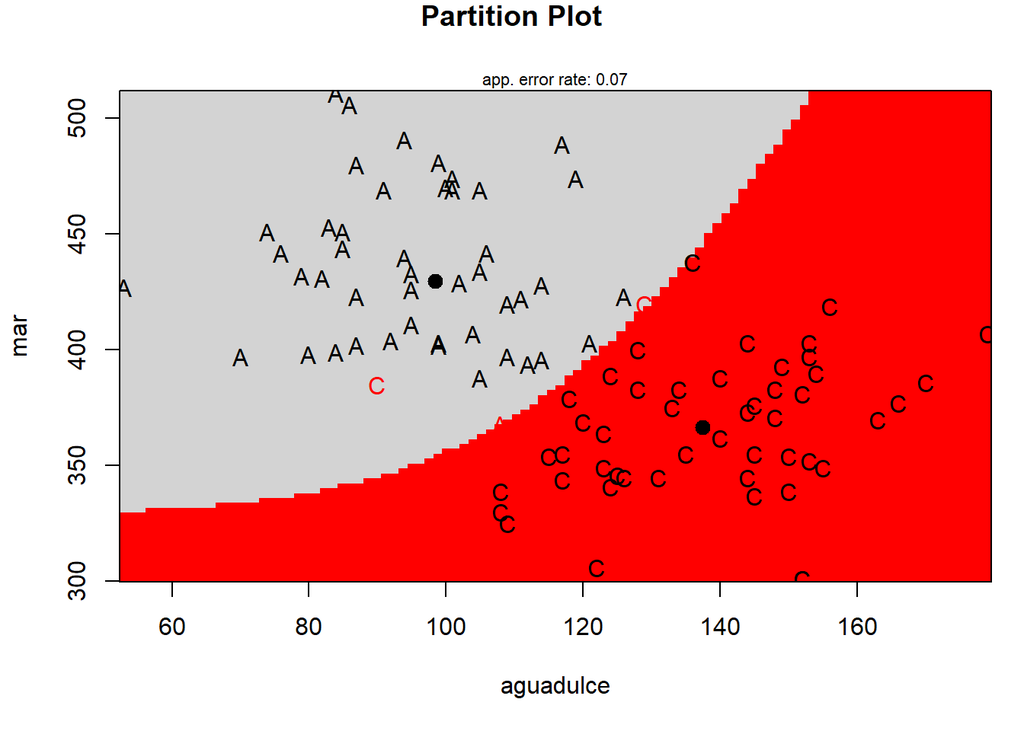

```r
library(klaR) # Classification and visualization package
Origen=factor(salmon$origen)
partimat(Origen ~ mar+aguadulce, data = salmon, method = "qda",
         imageplot = TRUE,col.mean=1,image.colors = c("lightgrey","red"))
```

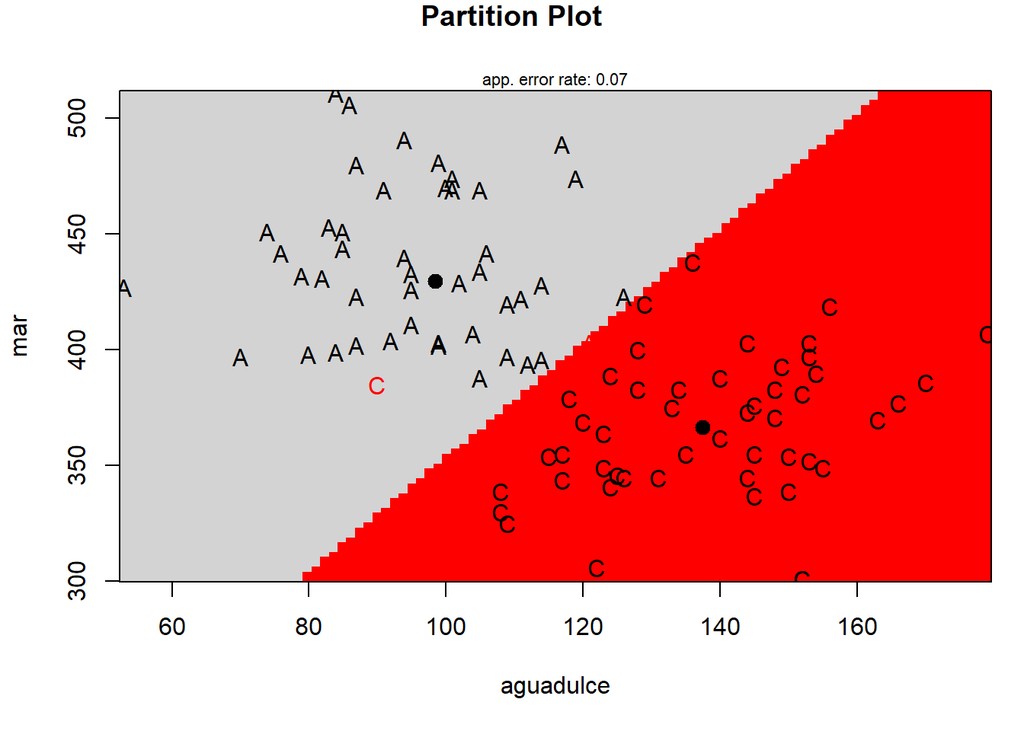

```r
partimat(Origen ~ mar+aguadulce, data = salmon, method = "lda", col.mean=1,
         imageplot = TRUE,image.colors = c("lightgrey","red"))
```

# Support vector machine

```r
library(ggplot2)
library(e1071)

Alaska0_Canada1<-ifelse(Origen[entrenamiento]=="Alaska",0,1)
Alaska0_Canada1_test<-ifelse(Origen[validación]=="Alaska",0,1)
```

Recordemos algunos parámetros importantes de la función svm.

**type:**

C-classification (default para clasificación)

nu-classification

one-classification (for novelty detection)

eps-regression (default para regresión)

nu-regression

**kernel:**

radial (default)

linear

polynomial

radial basis

sigmoid

**gamma:**

parámetro necesario para todos los kernels excepto el lineal (default: 1/(cantidad de variables)).

**cost:**

costo de violación de restricciones (default: 1). Es el valor ‘C’ (constante del término de regularización en la fórmula de optimización de Lagrange).

```r
modelo_svm=svm(as.factor(Alaska0_Canada1)~mar+aguadulce,data=salmon[entrenamiento,],method="C-classification",kernel="radial",cost=10,gamma=.1)
pred_svm=predict(modelo_svm, salmon[validación,-1])
table(salmon$origen[validación], pred_svm, dnn = c("Origen real", "Origen predicho"))
```

```
##            Origen predicho
## Origen real  0  1
##      Alaska 13  0
##      Canada  4 13
```

```r
error_svm<- mean(Alaska0_Canada1_test!= pred_svm) * 100
error_svm
```

```
## [1] 13.33333
```

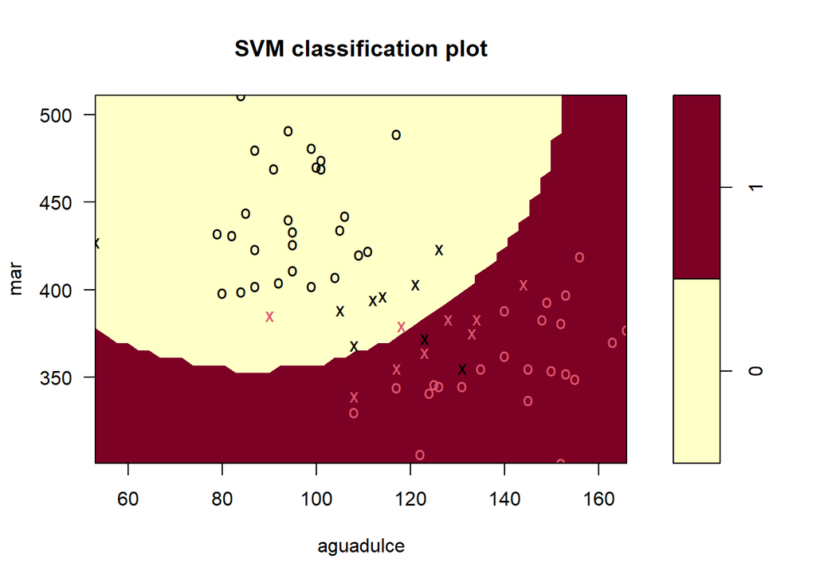

```r
#plot(modelo_svm,salmon[entrenamiento,],symbolPalette=topo.colors(3),dataSymbol="o",color.palette=cm.colors)
plot(modelo_svm,salmon[entrenamiento,])
```

# GAMLSS: ejemplo adicional

## Malnutrición de niños en india (DHS, 1998-99)

Se emplea un conjunto de datos “india” (de Demographic and Health Survey, 1998-99) con el que se crea un modelo predictivo del índice de malnutrición infantil. El índice stunted growth se define como la diferencia estandarizada entre el crecimiento de un niño y el crecimiento medio (mediana) de todos los niños de la población a la que pertenece. Está considerado como una de las principales consecuencias de la malnutrición de las madres durante el embarazo o de los niños durante los primeros meses de vida. Valores negativos indican un retraso en el crecimiento del niño. Se crea un modelo para predecir el stunted growth en función de la edad e índice de masa corporal de la madre y de los niños durante los primeros meses de vida.

```r
library(gamboostLSS)
data(india)
datos <- india
head(datos)
```

|  | stunting | cbmi | cage | mbmi | mage | mcdist | mcdist_lab |
| --- | --- | --- | --- | --- | --- | --- | --- |
| 7448 | 0.98 | 16.06220 | 10 | 21.26 | 26 | 367 | Jalna |
| 23043 | 0.95 | 13.79388 | 4 | 19.43 | 26 | 418 | North Goa |
| 8237 | -2.79 | 17.64873 | 16 | 23.35 | 24 | 381 | Mumbai (Greater Mumbai) |
| 9206 | -3.13 | 16.93727 | 35 | 22.43 | 22 | 215 | Jaintia Hills |
| 4551 | -1.32 | 16.20755 | 28 | 17.05 | 27 | 458 | Malappuram |
| 21928 | -3.51 | 19.77523 | 8 | 18.64 | 20 | 223 | Patna |

```r
dim(india)
```

```
## [1] 4000    7
```

**stunting**

A numeric z-score for malnutrition, stunted growth to be more precise, which ranges from -6 to 6, where negative values represent malnourished children. Children with values below -2 are considered stunted (height-for-age).

**cbmi**

BMI of the child.(bmi= body mass index)

**cage**

Age of the child in months.

**mbmi**

BMI of the mother.

**mage**

Age of the mother in years.

```r
#install.packages("gamlss")
#install.packages("skimr")

library(gamlss)
library(tidyverse)
library(ggpubr)
library(skimr)
skim(datos)
```

Data summary

| Name | datos |
| --- | --- |
| Number of rows | 4000 |
| Number of columns | 7 |
| _______________________ |  |
| Column type frequency: |  |
| factor | 2 |
| numeric | 5 |
| ________________________ |  |
| Group variables | None |

**Variable type: factor**

| skim_variable | n_missing | complete_rate | ordered | n_unique | top_counts |
| --- | --- | --- | --- | --- | --- |
| mcdist | 0 | 1 | FALSE | 422 | 381: 91, 78: 77, 271: 48, 245: 44 |
| mcdist_lab | 0 | 1 | FALSE | 417 | Mum: 91, Del: 77, Aiz: 48, Imp: 44 |

**Variable type: numeric**

| skim_variable | n_missing | complete_rate | mean | sd | p0 | p25 | p50 | p75 | p100 | hist |
| --- | --- | --- | --- | --- | --- | --- | --- | --- | --- | --- |
| stunting | 0 | 1 | -1.75 | 1.68 | -5.99 | -2.87 | -1.76 | -0.65 | 5.64 | ▂▇▆▁▁ |
| cbmi | 0 | 1 | 15.52 | 2.05 | 10.03 | 14.23 | 15.36 | 16.60 | 25.95 | ▂▇▃▁▁ |
| cage | 0 | 1 | 17.23 | 10.07 | 0.00 | 8.00 | 17.00 | 26.00 | 35.00 | ▇▇▇▆▆ |
| mbmi | 0 | 1 | 19.81 | 2.96 | 13.14 | 17.85 | 19.36 | 21.21 | 39.81 | ▅▇▁▁▁ |
| mage | 0 | 1 | 24.41 | 5.30 | 13.00 | 21.00 | 24.00 | 27.00 | 49.00 | ▃▇▃▁▁ |

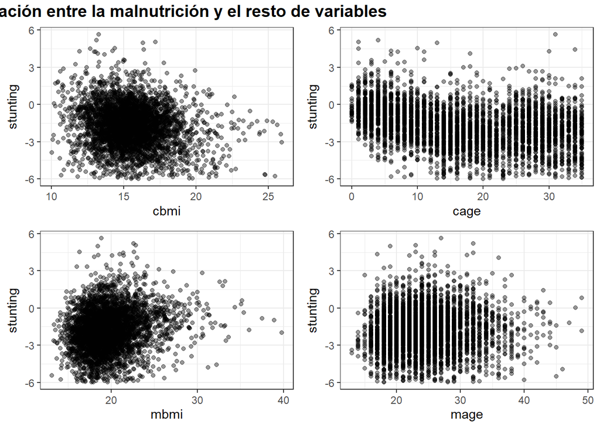

```r
p1 <- ggplot(data = datos, aes(x = cbmi, y = stunting)) +
  geom_point(alpha = 0.4) + labs(ttile = "Malnutrición vs IMC infantil") +
  theme_bw()
p2 <- ggplot(data = datos, aes(x = cage, y = stunting)) + geom_point(alpha = 0.4) +
  labs(ttile = "Malnutrición vs edad de los niños") + theme_bw()
p3 <- ggplot(data = datos, aes(x = mbmi, y = stunting)) + geom_point(alpha = 0.4) +
  labs(ttile = "Malnutrición vs IMC de las madres") + theme_bw()
p4 <- ggplot(data = datos, aes(x = mage, y = stunting)) + geom_point(alpha = 0.4) +
  labs(ttile = "Malnutrición vs edad de las madres") + theme_bw()

ggpubr::ggarrange( plotlist = list(p1, p2, p3, p4) ) %>%
  ggpubr::annotate_figure(
    top = text_grob("Relación entre la malnutrición y el resto de variables",
                    color = "Black", face = "bold", size = 14, x = 0.3) )
```

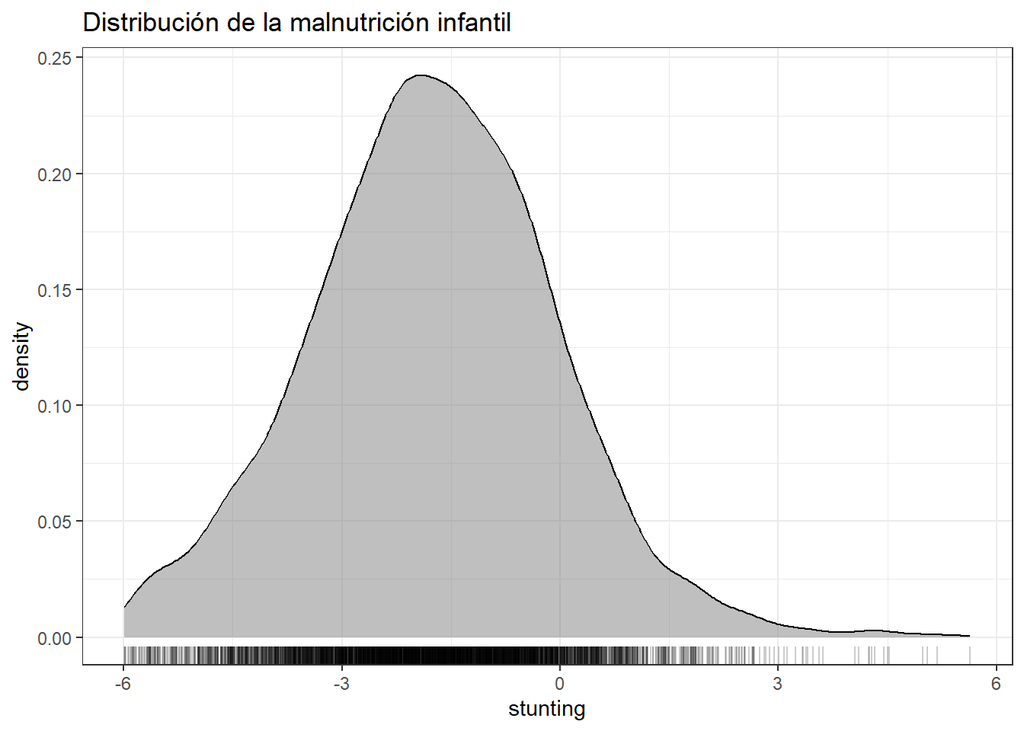

```r
ggplot(data = datos, aes(x = stunting)) + geom_density(alpha = 0.5, fill = "gray50") +
  geom_rug(alpha = 0.2) + labs(title = "Distribución de la malnutrición infantil") + theme_bw()
```

### Modelo lineal

```r
# El resultado es igual al obtenido con lm()
modelo_lm <- gamlss( formula = stunting ~ cbmi + cage + mbmi + mage,
                     family = NO, data = datos, trace = FALSE )
summary(modelo_lm)
```

```
## Family:  c("NO", "Normal")
##
## Call:  gamlss(formula = stunting ~ cbmi + cage + mbmi + mage,
##     family = NO, data = datos, trace = FALSE)
##
## Fitting method: RS()
##
## ------------------------------------------------------------------
## Mu link function:  identity
## Mu Coefficients:
##              Estimate Std. Error t value Pr(>|t|)
## (Intercept) -0.916070   0.251326  -3.645 0.000271 ***
## cbmi        -0.140622   0.011840 -11.877  < 2e-16 ***
## cage        -0.056160   0.002399 -23.411  < 2e-16 ***
## mbmi         0.118191   0.008290  14.257  < 2e-16 ***
## mage        -0.001196   0.004606  -0.260 0.795152
## ---
## Signif. codes:  0 '***' 0.001 '**' 0.01 '*' 0.05 '.' 0.1 ' ' 1
##
## ------------------------------------------------------------------
## Sigma link function:  log
## Sigma Coefficients:
##             Estimate Std. Error t value Pr(>|t|)
## (Intercept)  0.42291    0.01118   37.83   <2e-16 ***
## ---
## Signif. codes:  0 '***' 0.001 '**' 0.01 '*' 0.05 '.' 0.1 ' ' 1
##
## ------------------------------------------------------------------
## No. of observations in the fit:  4000
## Degrees of Freedom for the fit:  6
##       Residual Deg. of Freedom:  3994
##                       at cycle:  2
##
## Global Deviance:     14734.8
##             AIC:     14746.8
##             SBC:     14784.57
```

```r
paste("El valor estimado de la varianza es:", exp(0.42291))#1.5263969140621
```

```
## [1] "El valor estimado de la varianza es: 1.5263969140621"
```

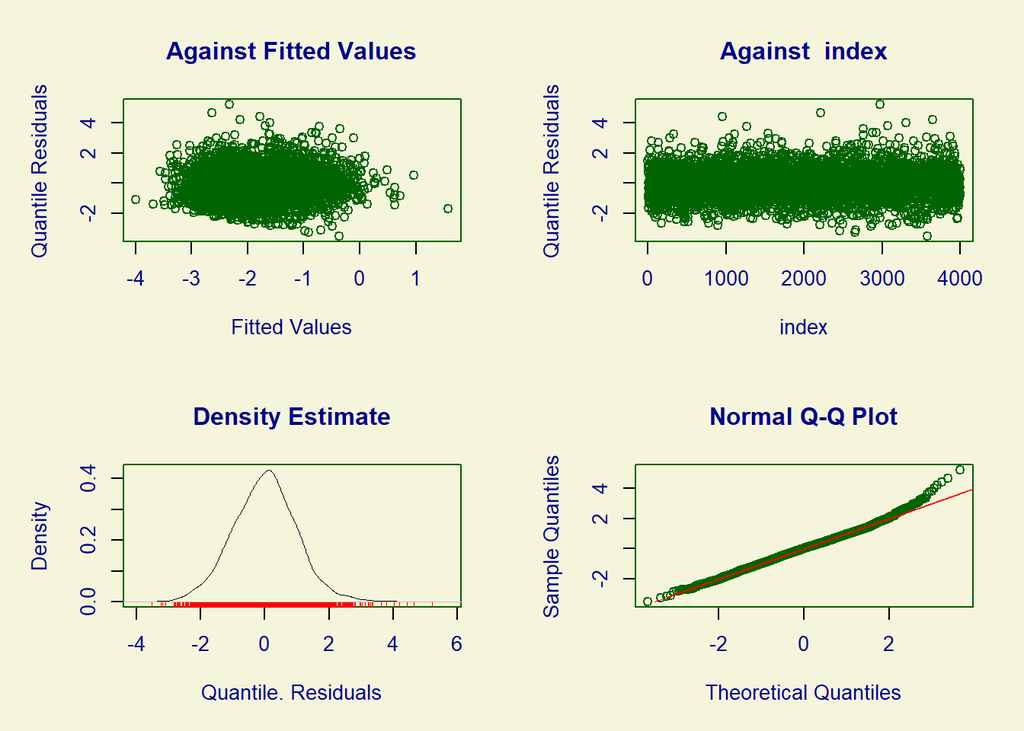

```
##        Summary of the Quantile Residuals
##                            mean   =  1.129003e-14
##                        variance   =  1.00025
##                coef. of skewness  =  0.1679035
##                coef. of kurtosis  =  3.673825
## Filliben correlation coefficient  =  0.997592
```

```r
plot(modelo_lm)
```

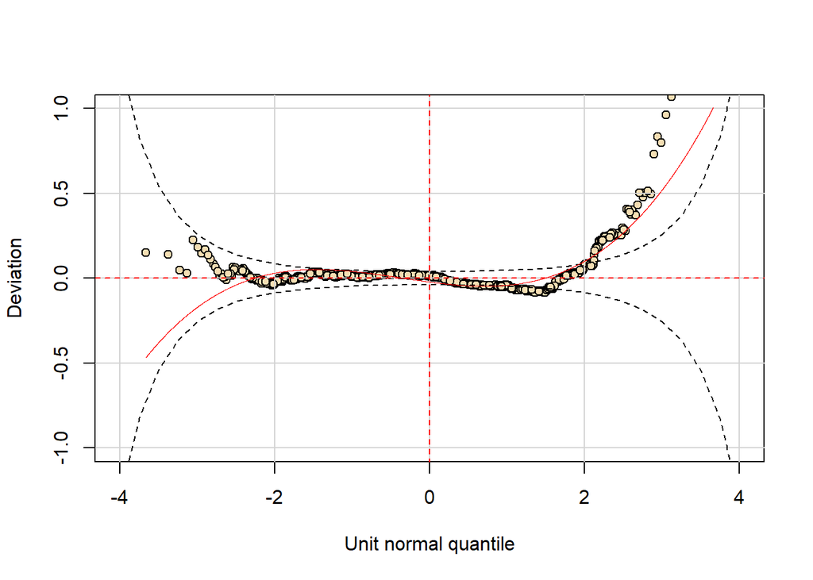

```r
# Worm plot de los residuos
wp(modelo_lm, ylim.all = 1)
```

### Modelo basado en la familia Normal

Usamos la distribución normal para la variable respuesta ya que es simétrica y toma valores positivos y negativos. Se emplea P-splines para los predictores continuos.

```r
modelo_gam <- gamlss( formula = stunting ~ pb(cbmi) + pb(cage) + pb(mbmi) + pb(mage),
                      family = NO, data = datos)
```

```
## GAMLSS-RS iteration 1: Global Deviance = 14494.15
## GAMLSS-RS iteration 2: Global Deviance = 14494.15
```

```r
summary(modelo_gam)
```

```
## Family:  c("NO", "Normal")
##
## Call:  gamlss(formula = stunting ~ pb(cbmi) + pb(cage) + pb(mbmi) +
##     pb(mage), family = NO, data = datos)
##
## Fitting method: RS()
##
## ------------------------------------------------------------------
## Mu link function:  identity
## Mu Coefficients:
##              Estimate Std. Error t value Pr(>|t|)
## (Intercept) -1.102929   0.243879  -4.522 6.29e-06 ***
## pb(cbmi)    -0.126393   0.011489 -11.001  < 2e-16 ***
## pb(cage)    -0.055929   0.002328 -24.026  < 2e-16 ***
## pb(mbmi)     0.116094   0.008045  14.431  < 2e-16 ***
## pb(mage)    -0.001052   0.004470  -0.235    0.814
## ---
## Signif. codes:  0 '***' 0.001 '**' 0.01 '*' 0.05 '.' 0.1 ' ' 1
##
## ------------------------------------------------------------------
## Sigma link function:  log
## Sigma Coefficients:
##             Estimate Std. Error t value Pr(>|t|)
## (Intercept)  0.39283    0.01118   35.14   <2e-16 ***
## ---
## Signif. codes:  0 '***' 0.001 '**' 0.01 '*' 0.05 '.' 0.1 ' ' 1
##
## ------------------------------------------------------------------
## NOTE: Additive smoothing terms exist in the formulas:
##  i) Std. Error for smoothers are for the linear effect only.
## ii) Std. Error for the linear terms maybe are not accurate.
## ------------------------------------------------------------------
## No. of observations in the fit:  4000
## Degrees of Freedom for the fit:  20.01023
##       Residual Deg. of Freedom:  3979.99
##                       at cycle:  2
##
## Global Deviance:     14494.15
##             AIC:     14534.17
##             SBC:     14660.12
```

```r
# Esta función puede tardar si hay muchos predictores no lineales o muchos datos.
drop1(modelo_gam, parallel = "multicore", ncpus = 4)
```

|  | Df | AIC | LRT | Pr(Chi) |
| --- | --- | --- | --- | --- |
|  | NA | 14534.17 | NA | NA |
| pb(cbmi) | 6.517085 | 14670.61 | 149.47315 | 2.380809e-29 |
| pb(cage) | 10.478648 | 15233.65 | 720.42892 | 7.321610e-148 |
| pb(mbmi) | 2.795897 | 14702.57 | 173.98681 | 1.108973e-37 |
| pb(mage) | 3.362660 | 14544.46 | 17.01205 | 1.035086e-03 |

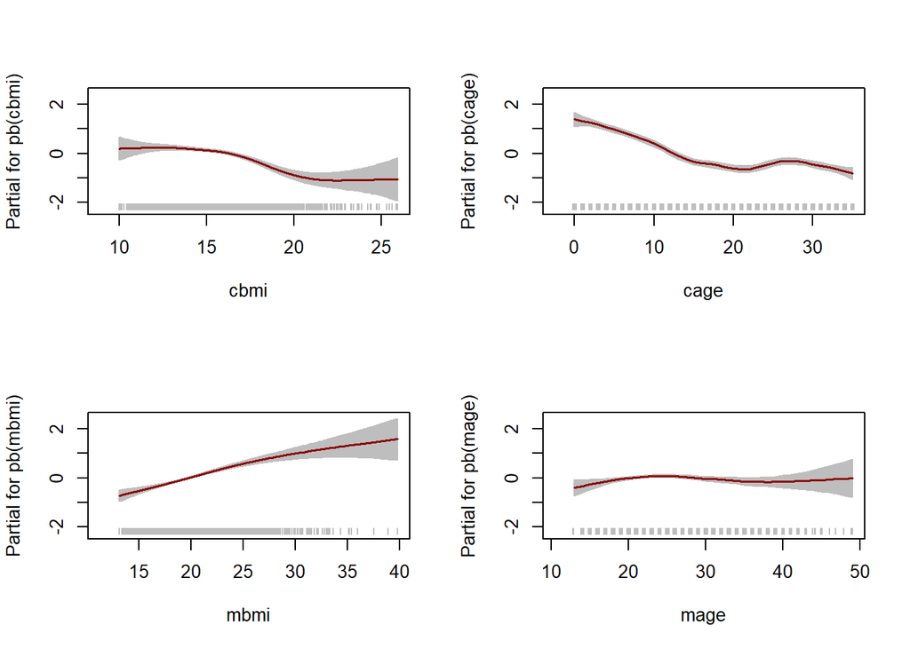

```r
term.plot(modelo_gam, pages = 1, ask = FALSE, rug = TRUE)
```

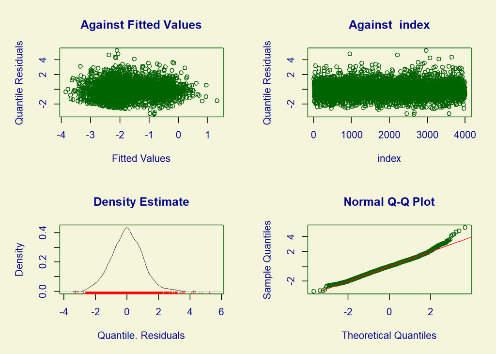

```
##        Summary of the Quantile Residuals
##                            mean   =  -2.096476e-14
##                        variance   =  1.00025
##                coef. of skewness  =  0.2440829
##                coef. of kurtosis  =  3.795075
## Filliben correlation coefficient  =  0.9965557
```

```r
plot(modelo_gam)
```

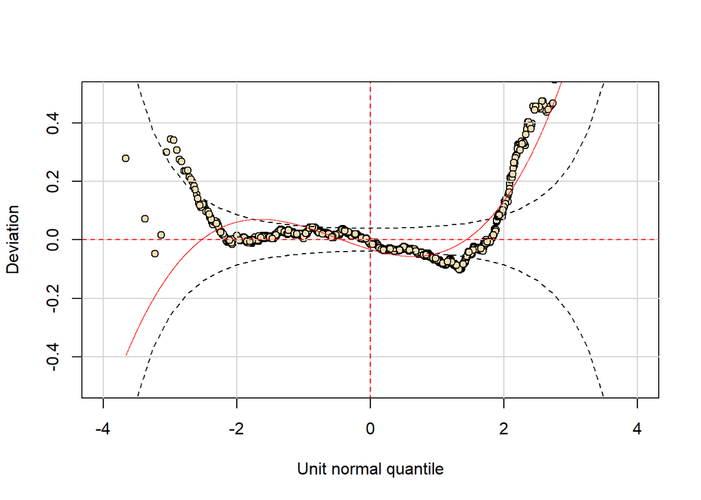

```r
# Worm plot de los residuos
wp(modelo_gam, ylim.all = 0.5)
```

Comparamos los modelos modelo_lm y modelo_gam.

```r
GAIC(modelo_lm, modelo_gam)
```

|  | df | AIC |
| --- | --- | --- |
| modelo_gam | 20.01023 | 14534.17 |
| modelo_lm | 6.00000 | 14746.80 |

### Modelos GAMLSS para distribución Normal ajustando parámetros de media mu y escala sigma

```r
modelo_gamlss <- gamlss( formula = stunting ~ pb(cbmi) + pb(cage) + pb(mbmi) + pb(mage),
                         sigma.formula = ~ pb(cbmi) + pb(cage) + pb(mbmi) + pb(mage),
                         family = NO, data = datos, trace = FALSE )
summary(modelo_gamlss)
```

```
## Family:  c("NO", "Normal")
##
## Call:  gamlss(formula = stunting ~ pb(cbmi) + pb(cage) + pb(mbmi) +
##     pb(mage), sigma.formula = ~pb(cbmi) + pb(cage) +
##     pb(mbmi) + pb(mage), family = NO, data = datos,      trace = FALSE)
##
## Fitting method: RS()
##
## ------------------------------------------------------------------
## Mu link function:  identity
## Mu Coefficients:
##               Estimate Std. Error t value Pr(>|t|)
## (Intercept) -1.1266315  0.2513805  -4.482 7.61e-06 ***
## pb(cbmi)    -0.1192513  0.0124200  -9.602  < 2e-16 ***
## pb(cage)    -0.0574240  0.0023252 -24.697  < 2e-16 ***
## pb(mbmi)     0.1118888  0.0077882  14.366  < 2e-16 ***
## pb(mage)    -0.0001638  0.0044721  -0.037    0.971
## ---
## Signif. codes:  0 '***' 0.001 '**' 0.01 '*' 0.05 '.' 0.1 ' ' 1
##
## ------------------------------------------------------------------
## Sigma link function:  log
## Sigma Coefficients:
##              Estimate Std. Error t value Pr(>|t|)
## (Intercept)  0.323967   0.118265   2.739  0.00618 **
## pb(cbmi)    -0.016155   0.005484  -2.946  0.00324 **
## pb(cage)     0.003243   0.001129   2.872  0.00410 **
## pb(mbmi)     0.007701   0.003905   1.972  0.04868 *
## pb(mage)     0.004011   0.002185   1.836  0.06648 .
## ---
## Signif. codes:  0 '***' 0.001 '**' 0.01 '*' 0.05 '.' 0.1 ' ' 1
##
## ------------------------------------------------------------------
## NOTE: Additive smoothing terms exist in the formulas:
##  i) Std. Error for smoothers are for the linear effect only.
## ii) Std. Error for the linear terms maybe are not accurate.
## ------------------------------------------------------------------
## No. of observations in the fit:  4000
## Degrees of Freedom for the fit:  28.91294
##       Residual Deg. of Freedom:  3971.087
##                       at cycle:  7
##
## Global Deviance:     14387.7
##             AIC:     14445.52
##             SBC:     14627.5
```

```r
drop1(modelo_gamlss, parameter = "sigma", parallel = "multicore", ncpus = 4)
```

|  | Df | AIC | LRT | Pr(Chi) |
| --- | --- | --- | --- | --- |
|  | NA | 14445.52 | NA | NA |
| pb(cbmi) | 4.213286 | 14514.69 | 77.598468 | 7.926357e-16 |
| pb(cage) | 1.305035 | 14459.79 | 16.880716 | 7.189853e-05 |
| pb(mbmi) | 2.803211 | 14453.78 | 13.865074 | 2.521667e-03 |
| pb(mage) | 1.013143 | 14446.88 | 3.386267 | 6.697940e-02 |

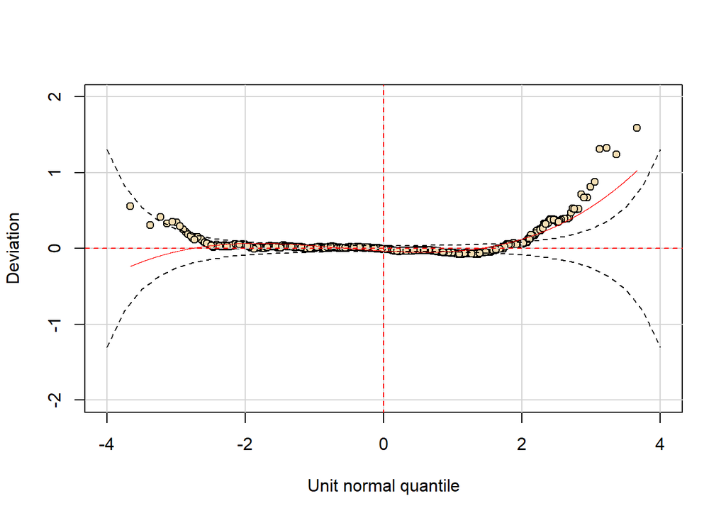

```r
modelo_gamlss2 <- gamlss( formula = stunting ~ pb(cbmi) + pb(cage) + pb(mbmi) + pb(mage),
                          mu.formula = ~ pb(cbmi) + pb(cage) + pb(mbmi),
                         sigma.formula = ~ pb(cbmi) + pb(cage) + pb(mbmi),
                         family = NO, data = datos, trace = FALSE )

# Worm plot de los residuos
wp(modelo_gamlss2, ylim.all = 2)
```

Comparamos los modelos modelo_lm, modelo_gam, modelo_gamlss y modelo_gamlss2.

```r
GAIC( modelo_lm, modelo_gam, modelo_gamlss,modelo_gamlss2 )
```

|  | df | AIC |
| --- | --- | --- |
| modelo_gamlss | 28.91294 | 14445.52 |
| modelo_gamlss2 | 27.89980 | 14446.88 |
| modelo_gam | 20.01023 | 14534.17 |
| modelo_lm | 6.00000 | 14746.80 |

### Nuevo modelo GAMLSS para distribución Normal ajustando parámetros de media y escala

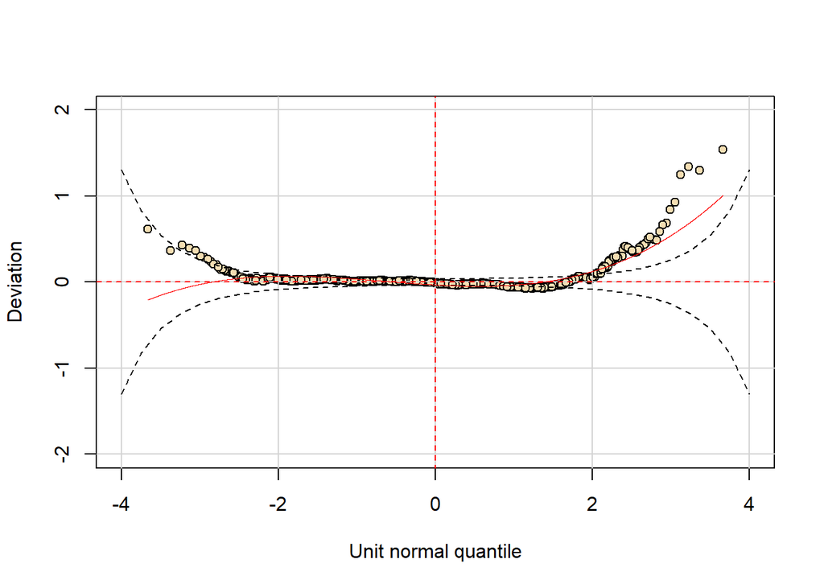

```r
modelo_gamlss3 <- gamlss( formula = stunting ~ pb(cbmi) + pb(cage) + pb(mbmi),
                          mu.formula = ~ pb(cbmi) + pb(cage) + pb(mbmi),
                          sigma.formula = ~ pb(cbmi) + pb(cage) + pb(mbmi),
                          family = NO, data = datos, trace = FALSE )

wp(modelo_gamlss3, ylim.all = 2)
```

Comparamos los modelos modelo_lm, modelo_gam, modelo_gamlss y modelo_gamlss3.

```r
GAIC( modelo_lm, modelo_gam, modelo_gamlss,modelo_gamlss3 )
```

|  | df | AIC |
| --- | --- | --- |
| modelo_gamlss | 28.91294 | 14445.52 |
| modelo_gamlss3 | 24.42026 | 14458.20 |
| modelo_gam | 20.01023 | 14534.17 |
| modelo_lm | 6.00000 | 14746.80 |

### Modelo GAMLSS para distribución T de student ajustando parámetros de media y escala

La distribución T de student para la variable respuesta también sirve porque es simétrica y toma valores positivos y negativos. Nuevamente se utilizan P-splines para los predictores continuos.

```r
modelo_gamlss4 <- gamlss( formula = stunting ~ pb(cbmi) + pb(cage) + pb(mbmi) + pb(mage),
                          mu.formula = ~ pb(cbmi) + pb(cage) + pb(mbmi)+ pb(mage),
                          sigma.formula = ~ pb(cbmi) + pb(cage) + pb(mbmi)+ pb(mage),
                          family = TF, data = datos, trace = FALSE )

drop1(modelo_gamlss4, parameter = "sigma", parallel = "multicore", ncpus = 4)
```

|  | Df | AIC | LRT | Pr(Chi) |
| --- | --- | --- | --- | --- |
|  | NA | 14409.58 | NA | NA |
| pb(cbmi) | 4.653378 | 14467.13 | 66.855644 | 2.802585e-13 |
| pb(cage) | 1.296830 | 14424.89 | 17.899069 | 4.178743e-05 |
| pb(mbmi) | 2.627244 | 14414.12 | 9.797856 | 1.448490e-02 |
| pb(mage) | 1.063071 | 14411.07 | 3.614599 | 6.262002e-02 |

```r
drop1(modelo_gamlss4, parameter = "mu", parallel = "multicore", ncpus = 4)
```

|  | Df | AIC | LRT | Pr(Chi) |
| --- | --- | --- | --- | --- |
|  | NA | 14409.58 | NA | NA |
| pb(cbmi) | 5.331928 | 14509.66 | 110.74534 | 4.921220e-22 |
| pb(cage) | 2.925138 | 15132.75 | 729.01865 | 8.587935e-158 |
| pb(mbmi) | 3.209095 | 14569.39 | 166.23168 | 1.304867e-35 |
| pb(mage) | 3.537665 | 14423.45 | 20.94325 | 2.000788e-04 |

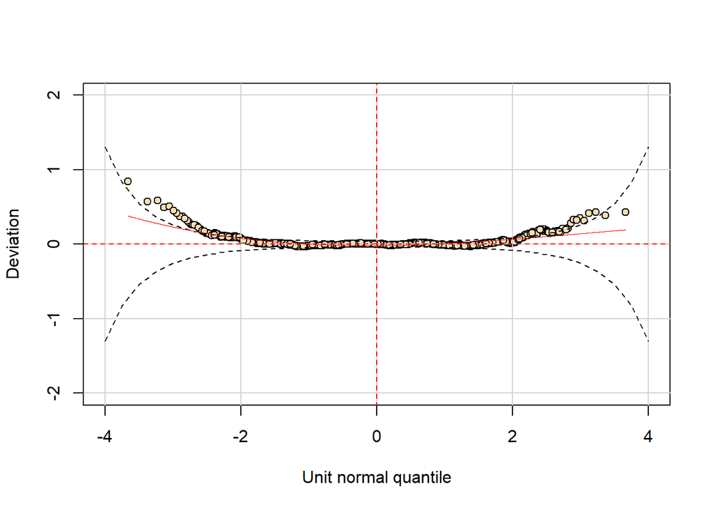

```r
# Worm plot de los residuos
wp(modelo_gamlss4, ylim.all = 2)
```

Comparamos los modelos modelo_lm, modelo_gam, modelo_gamlss y modelo_gamlss4.

```r
GAIC( modelo_lm, modelo_gam, modelo_gamlss,modelo_gamlss4 )
```

|  | df | AIC |
| --- | --- | --- |
| modelo_gamlss4 | 30.27689 | 14409.58 |
| modelo_gamlss | 28.91294 | 14445.52 |
| modelo_gam | 20.01023 | 14534.17 |
| modelo_lm | 6.00000 | 14746.80 |

El modelo modelo_gamlss4 es el de menor GAIC entre todos los evaluados.